# Tugas Praktikum 4 - Proses MA(2)

Fitria Angelita Delvi

2026-09-23

# 1. Bangkitkan MA(2) secara manual

```r
set.seed(123)

n <- 300

e <- rnorm(n + 2, mean = 0, sd = 1)

Y_manual <- numeric(n)

for (t in 1:n) {
  Y_manual[t] <- e[t + 2] +
    0.4 * e[t + 1] +
    0.6 * e[t]
}

head(Y_manual)
```

```
## [1]  1.13035193  0.55588522  1.09271608  1.80908512  1.22451484 -0.05165576
```

Berdasarkan hasil pembangkitan secara manual, diperoleh 300 data dari proses MA(2) dengan parameter $\theta_1=0.4$ dan $\theta_2=0.6$. Enam pengamatan pertama menunjukkan nilai yang berfluktuasi, baik positif maupun negatif. Fluktuasi tersebut terjadi karena nilai $Y_t$ dipengaruhi oleh error pada periode sekarang serta dua periode sebelumnya, yaitu $e_t$, $e_{t-1}$, dan $e_{t-2}$.

# 2. Bangkitkan MA(2) dengan arima.sim

```r
set.seed(123)

Y_arima <- arima.sim(
  model = list(ma = c(0.4, 0.6)),
  n = 300
)

head(Y_arima)
```

```
## Time Series:
## Start = 1
## End = 6
## Frequency = 1
## [1]  1.13035193  0.55588522  1.09271608  1.80908512  1.22451484 -0.05165576
```

Berdasarkan hasil pembangkitan menggunakan fungsi arima.sim(), diperoleh 300 data dengan model MA(2) dan parameter $\theta_1=0.4$ serta $\theta_2=0.6$. Pembangkitan dengan arima.sim() digunakan sebagai cara otomatis untuk menghasilkan data dari model MA(2). Hasilnya memiliki karakteristik yang sama dengan model MA(2) yang dibangkitkan secara manual.

# 3. Plot Time Series

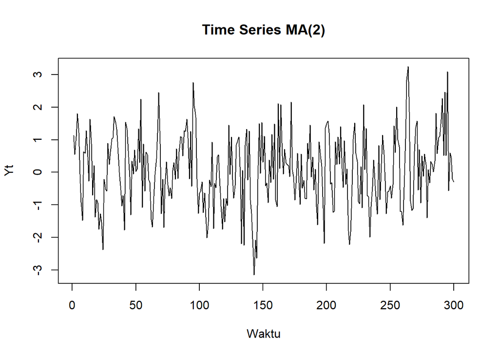

```r
plot(Y_manual,
     type = "l",
     main = "Time Series MA(2)",
     xlab = "Waktu",
     ylab = "Yt")
```

Berdasarkan plot time series, data MA(2) berfluktuasi di sekitar nilai rata-rata yang relatif konstan. Tidak terlihat adanya tren naik maupun tren turun yang sistematis dan variabilitas data relatif stabil sepanjang waktu. Oleh karena itu, berdasarkan plot time series, data dapat dikatakan stasioner.

# 4. Plot ACF

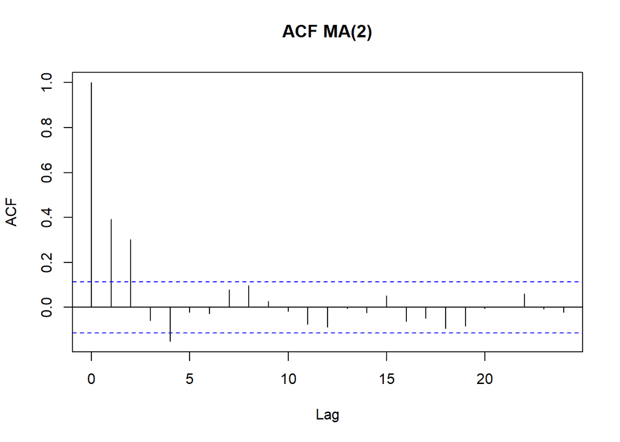

```r
acf(Y_manual,
    main = "ACF MA(2)")
```

# 5. Plot PACF

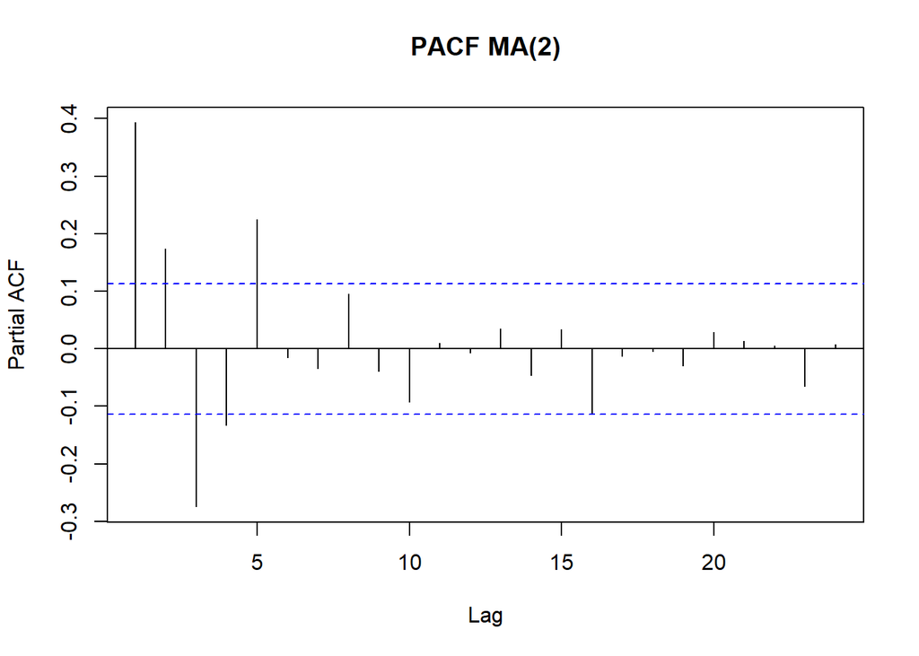

```r
pacf(Y_manual,
     main = "PACF MA(2)")
```

Berdasarkan plot PACF, terlihat beberapa spike pada lag awal, kemudian nilai partial autocorrelation cenderung mengecil dan berfluktuasi di sekitar nol. Tidak terdapat pola cut-off yang jelas pada lag tertentu. Dengan demikian, PACF menunjukkan pola tailing off, yang sesuai dengan karakteristik proses MA(2).

# 6. Plot EACF

```r
library(TSA)
```

```r
eacf(Y_manual)
```

```
## AR/MA
##   0 1 2 3 4 5 6 7 8 9 10 11 12 13
## 0 x x o x o o o o o o o  o  o  o
## 1 x x x x o o o o o o o  o  o  o
## 2 x x o x o o o o o o o  o  o  o
## 3 x x o o x o o o o o o  o  o  o
## 4 x x x x x o o o o o o  o  o  o
## 5 o x x x x o o o o o o  o  o  o
## 6 x o x x o o o o o o o  o  o  o
## 7 x x o x x o o o o o o  o  o  o
```

Berdasarkan hasil EACF, identifikasi dilakukan dengan melihat pola segitiga o pada tabel EACF. Pada posisi $(p,q)=(0,2)$ diperoleh simbol o, sehingga kandidat model yang diperoleh adalah ARMA(0,2), yang ekuivalen dengan MA(2). Hasil EACF tersebut sesuai dengan model yang digunakan dalam pembangkitan data.

# 7. Membuat Lag

```r
Y_t  <- Y_manual[4:300]
Y_t1 <- Y_manual[3:299]
Y_t2 <- Y_manual[2:298]
Y_t3 <- Y_manual[1:297]
```

# 8. Scatterplot Yt dengan Yt-1

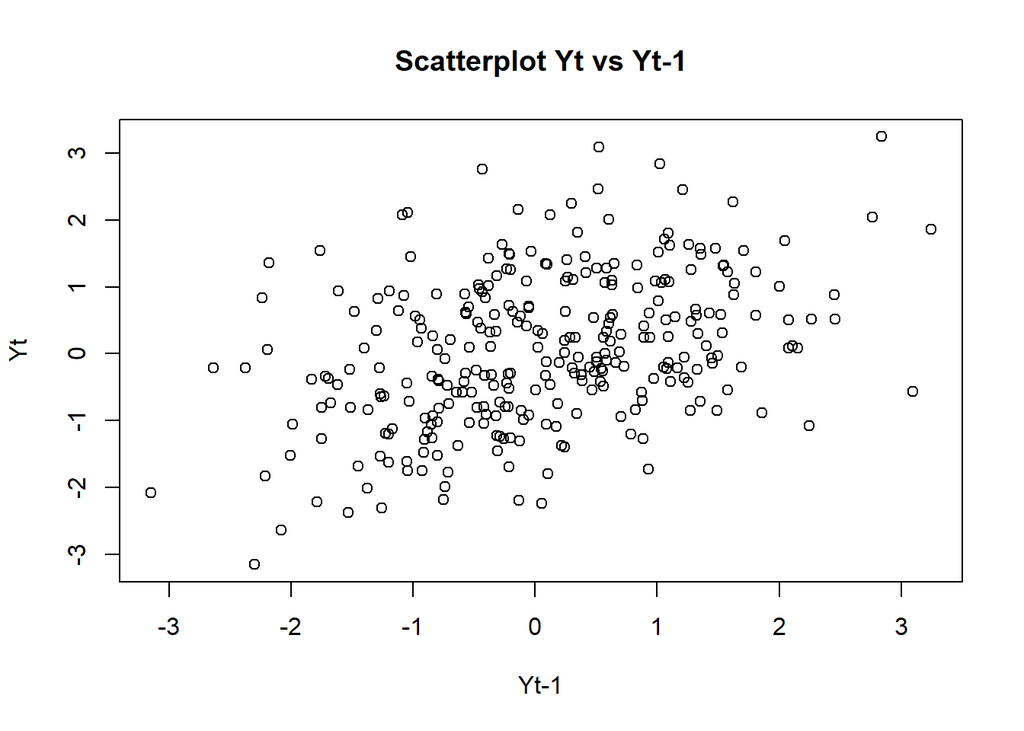

```r
plot(
  Y_t1,
  Y_t,
  main = "Scatterplot Yt vs Yt-1",
  xlab = "Yt-1",
  ylab = "Yt"
)
```

Berdasarkan scatterplot $Y_t$ terhadap $Y_{t-1}$, terlihat adanya kecenderungan hubungan linear positif. Artinya, ketika nilai $Y_{t-1}$ meningkat, nilai $Y_t$ cenderung ikut meningkat. Namun, titik-titik masih cukup menyebar sehingga hubungan tersebut tidak bersifat sempurna. Hasil ini sesuai dengan autokorelasi lag 1 yang bernilai positif.

# 9. Scatterplot Yt dengan Yt-2

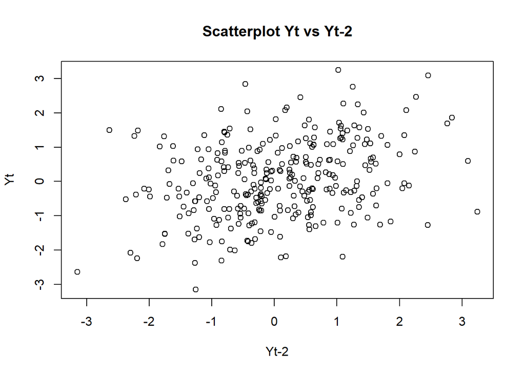

```r
plot(
  Y_t2,
  Y_t,
  main = "Scatterplot Yt vs Yt-2",
  xlab = "Yt-2",
  ylab = "Yt"
)
```

Berdasarkan scatterplot $Y_t$ terhadap $Y_{t-2}$, terlihat adanya kecenderungan hubungan linear positif meskipun titik-titik pengamatan cukup menyebar. Hal ini menunjukkan bahwa $Y_t$ masih memiliki hubungan dengan $Y_{t-2}$. Hasil tersebut sesuai dengan karakteristik MA(2), karena autokorelasi pada lag 2 masih bernilai positif. Secara teoritis, nilai autokorelasi pada lag 2 adalah sebesar 0,3947.